# 民主政治 民主的維繫與前景

師大公領系教授 黃信豪

2020/12

### Topics

**一、「第三波」後的發展**  
**二、民主的近況與前景：各區域的現況與問題**

**指定閱讀：民主的精神，Ch.3, 8-12。**

# 一、「第三波」後的發展

### （一）「第三波」的發生與意義

- 時間：近20年(1970中-90中)；各國發生民主轉型的脈絡、原因大不同，可分兩群(groups)理解：
  - 1.歐洲、拉美、東$\backslash$南亞等地區 $\rightarrow$ 軍$\backslash$強人專政、大多在90年代之前。
  - 2.匈牙利、蘇聯瓦解、東歐 $\rightarrow$ 共產主義政權。起因：
    - (1)匈牙利開放奧地利邊界。
    - (2)戈巴契夫的自由化政策。
    - (3)東歐有活力的公民社會、原有的民族意識。
  - 時間較晚(1989-1994)，連帶帶動非洲國家轉型(1990-)。
- 成果與意義：
  - 1.民主國家數量增加：6X $\rightarrow$ 8X。
  - 2.地區分散。
  - 3.回潮數量相對少（或快速恢復）。

### （二）「第三波」民主回潮/瓦解

- 「巴基斯坦」（Pakistan）的案例與意涵：第五大國、具核武、伊斯蘭基本教義派的重要根據地。
  - 民主被推翻：1999/10軍隊發起政變，民眾、媒體支持度高。反映新興民主國家的政府**治理問題**(governance issues)：政治鬥爭、貧富差距大、司法與法治不獨立、族群分化嚴重等…
  - 2008年重新建立文人政府。
- 第三波民主化案例「倒退」的概述：
  - 20國民主制度曾中斷，8個恢復(2007年底)。
- (*民主的精神*，頁60)

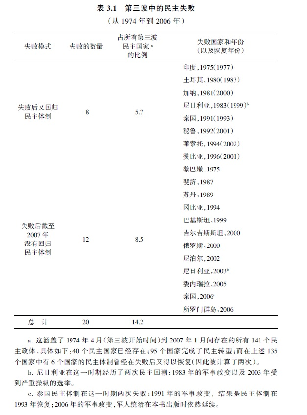

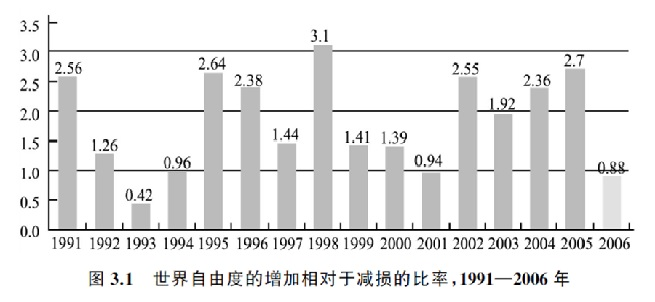

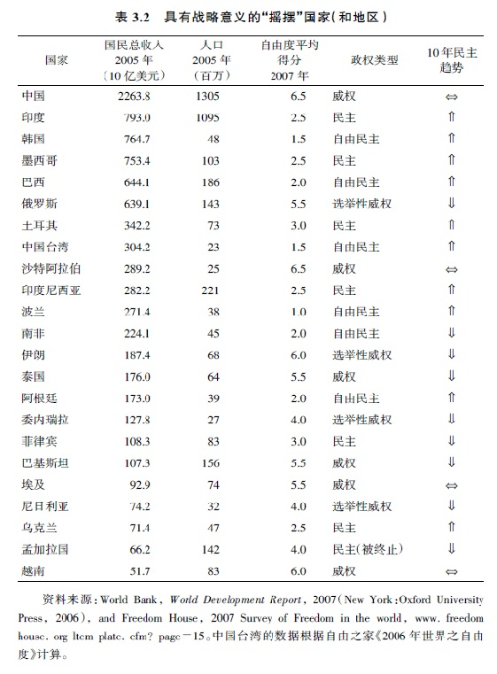

### （三）民主倒退的案例

#### 1.俄羅斯

- 概況：脆弱的政黨、總統權力過大、冷漠的公民社會、缺少獨立的司法機關與媒體監督、民眾對民主的支持度下降。
- 發展背景與經歷：
  - 前蘇聯的快速私有化與葉爾欽98年的經改失敗：葉與非自由派人士合作以保障財產與安全。
  - 普丁的崛起：前KGB負責人、1999被任命為總理、2000提前舉辦總統大選 $\rightarrow$ 煽動民族主義，贏得選舉。
  - 對民主的傷害：**破壞政治的多元性**、**權力制衡的基礎**
    - (1)將獨立選舉的地方官員替換成為官派（上議院89席）。
    - (2)建立七個「超級地區」並由官方任命行政首長 $\rightarrow$ 建立個人化統治集團
    - (3)利用政治力量掃除、收買收編官商寡頭階級與媒體。
  - 不利於多元政黨的制度、法規。
- 已成「不自由」國家。

#### 2.委內瑞拉

- 概況：軍事強人執政、政治腐敗動盪、石油資源被壟斷、經濟衰退、通膨嚴重、國際勢力介入。
- 發展背景與經歷：
  - 軍事強人查維茲上台：1998年透過選舉當選總統 $\to$ 廢止舊有憲法、創立新憲法來擴權，1999/12公投通過。
  - 政變失敗：2002年公民團體抗議示威運動，發動全國總罷工、罷免投票等方式 $\rightarrow$ 失敗。查2007、13年再度當選總統。13年逝世馬杜羅接任並改選獲當選、 2017/4反對陣營再次發動大規模抗議。
  - 社會經濟發展：長期依賴石油，出現**荷蘭病**，查病逝後經濟開始不穩（通貨膨脹、物資短缺…），美國經濟制裁加大(2017)。201704的[大規模示威抗議](https://global.udn.com/global_vision/story/8662/2414419)。
  - 201805總統大選：馬杜羅贏得連任，反對派選前要求抵制選舉，投票率明顯低落 $\rightarrow$ 國際各國紛紛表態。
  - 201904反對派發動政變，政府鎮壓。
  - [202012國會改選，執政黨壓倒性勝利](https://www.cna.com.tw/news/aopl/202012080270.aspx)。

#### 3.尼日

- 概況：石油資源帶來的政治腐敗、嚴重的選舉舞弊、政治暴力與犯罪、現任者企圖透過修憲來擴張權力。
- 頻仍的軍事政變：1966-1999年的第一至第四共和國中三次軍事政變（2010年第四次）
  - 舞弊 $\rightarrow$ 民眾普遍對民主失望 $\rightarrow$ 軍事政變 $\rightarrow$恢復民選…。
- 選舉舞弊、官員腐敗：官員掌握石油資源分配 $\rightarrow$ 贏得選舉 $\rightarrow$ 為持續掌握權力 $\rightarrow$ 侵害民主作為。

#### 4.泰國

- 概況：強而有力的王室、統一的軍隊與成功軍事政變的歷史。
- 發展背景與經歷：
  - 塔克辛（塔信）的掌權：97年亞洲金融風暴、塔克辛塑造打擊舊政治集團的形象掌握了民粹支持，2001當選總理、泰愛泰黨成為第一大黨(至2005年超過3/4席次) $\rightarrow$ 軍方、王室感到威脅。
  - 貪腐醜聞：2006年被控貪腐、公民社會走向街頭，要求下台或接受彈劾。塔克辛突然宣布解散議會並在4月快速選舉，出現憲政危機。[泰國特殊的投票制度](https://buzzorange.com/2016/09/12/tailand-voting/)
  - 軍方政變與發展：(1)2006年9月軍隊發動政變（來自皇室的支持）。(2)2011年恢復選舉，「為泰黨」過半、盈拉成為女總理。(3)2013年反政府示威，盈拉解散國會重新改選，被宣告違憲而無效。(4)2014年5月憲法法庭指控盈拉濫權，下台（實為軍方政變）。
    - [泰國政爭十年動盪](http://www.coolloud.org.tw/node/77572)
  - 2019年大選：泰國新選制：(1)降低政黨票對總席次的影響；(2)軍方已先擁有1/3的席次。
    - [泰國新選舉制度(上)](https://asean.thenewslens.com/feature/2019thaielection/115393)、[泰國新選舉制度(下)](https://asean.thenewslens.com/feature/2019thaielection/115845)
    - 選舉結果：投票率66%（低於上屆），親軍政府派、保守派勝利 $\rightarrow$ 透過民主機制取得正當性，但政治兩極化現象未減。
    - [2020年泰國反政府運動](https://visionthai.net/zh-hans/article/2020-thailand-protests/)。

### （四）特別的石油詛咒

- 對經濟依賴（出口）的23個石油輸出國家：沒有一個採行民主制度 $\rightarrow$ 石油收入增加，民主更呈現衰退現象。Why?
- 對石油的依賴度愈大，則該國經濟發展不平衡的程度就會愈大，特別是**中產階級**的角色：
  - 西方國家的中產階級：經濟獨立。
  - 石油國家的中產階級：高度依賴政府，國民收入被政商混合的集團所控制/收買（利益共生）。
- 政治後果：
  - 1.政府資源控制，公民社會的形成受壓制。
  - 2.資源私相收授，政治腐敗。
  - 3.集中石油產業、產業不平均。
  - 4.菁英爭奪資源、國家內戰可能性增。
  - 5.政府、民眾的徵稅關係消失 $\rightarrow$ 政府作為不需回應民眾需求、不利民眾問責。
  - 6.政府缺乏人力資源投資的動機。
- 發展：石油國家僅是單純收入增加，並非社會經濟結構產生「實質」轉變 $\rightarrow$ 民主體制無法被**培育**。

# 二、民主的近況與前景

### （一）拉美

- 1.民主的正面訊息：擁有競爭性選舉，政權也多能順利轉移，對選舉過程與獨立選舉機構的尊重與日俱增，軍隊干政的情況減少（部分則否）。
  - 大眾的態度：支持民主體制、政治效能感程度不低、對**個人**信任高於**體制**。
  - 各地差異：中美洲國家、安地斯山脈國家民主較脆弱 $\rightarrow$ 殖民者的「制度遺產」是重要解釋因素。
- 2.治理問題：
  - (1)貧窮與財富分配不均問題。
  - (2)缺乏健全、效能的司法體系：毒品、幫派問題嚴重 $\rightarrow$ 侵害公民權。
  - (3)基礎建設差，國家整體治理能力弱。
- 小結：民主的**績效正當性**有待加強，民主穩固、深化，仰賴良好治理。

### （二）後共黨國家

- 1.從東歐、俄羅斯至中亞：各地差異大，以1939年蘇聯─歐洲邊界為區隔：

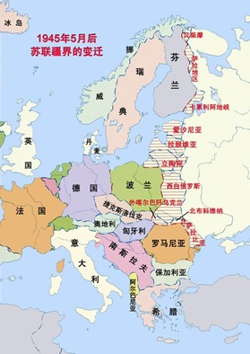

- - 以西：15/16是民主國家。
  - 以東：9/12個是威權國家（前蘇聯加盟國），另3個民主國家不穩定。差異：歷史與文化傳統。
- 2.發展概況：
  - (1)民眾對政黨、政治機構抱持懷疑；市場改革的受益者、受害者形成對立 $\rightarrow$ 左翼（恢復共產）、右翼（民族主義排外）的反自由民粹運動增加。
  - (2)缺乏穩定政黨體系、政黨快速更替。
  - (3)外力的影響：歐盟的要求。
- 3.發展前景：**中東歐國家**民主走向穩固可能性高；**歐亞交界**維持「選舉式民主」；**其他中亞國家**高度依賴俄羅斯。

### （三）亞洲國家

- 1.呈現高度的政體複雜性、多元性：**民主危機**、**民主鞏固國家**、**威權國家**穩定並存。
  - 新加坡模式？1993年李光耀所指出的**Confucian Democracy** $\rightarrow$ 維持高度經濟成長、較少的腐敗、社會安全體系+國家高度控制的媒體、有利執政黨的選舉制度 $\rightarrow$ 透過滿足民眾對政府「績效」的期待，降低對「程序」的要求。
- 2.儒家文化的影響：人民對「萬能政府」有所期待、不利自主的公民社會發展 $\rightarrow$ 多數的民眾支持民主價值，但對威權統治的排斥明顯較弱。
  - 傳統價值：重視「治理」（中國自古以來的民本思想vs.民主思想？）
- 小結：民主體制的穩固、深化，仰賴良好治理；民主的出現更仰賴治理失敗。

### （四）非洲國家

- 個人統治：部落化社會、個人派系與關係網絡。
  - (1)石油+外國援助：政治菁英與其親信上下其手 $\rightarrow$ 建立個人化的**恩庇侍從體系(Patron-Client system)** ，統治者多長期執政。
  - (2)90年代以後的發展：選舉逐漸常規化，多有競爭；民主意識提高、媒體逐漸發展。
- 未來前景：腐敗的控制、如何建立監督制衡機制，而非權力集中於個人？
  - 中東國家：亦高度個人獨裁，但來源不同（宗教因素）；國際政治因素。

# 三、小結

- 第三波後發展的啟示：民主深化是未竟的事業 $\rightarrow$ (1)慎防民選領袖破壞民主制度、程序；(2)軍人的中立角色。
- 民主的**績效正當性**在新興民主國家特別重要：由於個人政治經驗，在多數民眾心中「民主政體」是可被取代的（政體競爭性）。
- 不同地區的前景：差異
  - 1.石油輸出國：政府掌握資源 $\rightarrow$ 不利社會多元、健全發展。
  - 2.拉美：國家治理能力。
  - 3.後共黨國家：國際影響（歐盟、俄羅斯）。
  - 4.亞洲：傳統儒家價值 $\rightarrow$ 重視績效。
  - 5.非洲：擺脫個人化、落實國家建制、制度。